# EasyVisa_ML_model

## Feature Scaling

```python
#Check Training Data Imbalance
print("Training Class Distribution:")
print(y_train.value_counts())
```

```
Training Class Distribution:
case_status
1    13600
0     6757
Name: count, dtype: int64
```

This distribution indicates that the training set successfully mirrors the original data's proportions, maintaining a 2:1 ratio of certified to denied cases. With 13,600 "Certified" entries (approx. 66.8%) and 6,757 "Denied" entries (approx. 33.2%), the data is moderately imbalanced.

```python
#Correct Imbalance Using SMOTE
from imblearn.over_sampling import SMOTE

smote = SMOTE(random_state=42)

X_train_balanced, y_train_balanced = smote.fit_resample(X_train, y_train)
```

```python
#Check Balanced Data
print("Training Data Distribution After Balancing:")
print(y_train_balanced.value_counts())
```

```
Training Data Distribution After Balancing:
case_status
1    13600
0    13600
Name: count, dtype: int64
```

The training data is now perfectly balanced, with an equal number of samples ($13,600$) for both the Certified (1) and Denied (0) classes.

```python
#Balanced Training Data For Modeling
```

```python
from sklearn.tree import DecisionTreeClassifier
from sklearn.ensemble import RandomForestClassifier
from sklearn.ensemble import BaggingClassifier
from sklearn.ensemble import AdaBoostClassifier
from sklearn.ensemble import GradientBoostingClassifier

from sklearn.metrics import accuracy_score, classification_report, confusion_matrix
```

```python
print("Training shape:", X_train.shape)
print("Testing shape:", X_test.shape)
```

```
Training shape: (20357, 18)
Testing shape: (5090, 18)
```

This confirms a standard 80/20 data split, providing 20,357 rows for the model to learn from and 5,090 unseen rows for testing.

The 18 columns show that both sets are perfectly aligned with the same features for consistent prediction.

```python
#Create Evaluation Function
def evaluate_model(model, X_train, X_test, y_train, y_test):

    model.fit(X_train, y_train)

    y_pred_train = model.predict(X_train)
    y_pred_test = model.predict(X_test)

    print("Model:", model)
    print("Training Accuracy:", accuracy_score(y_train, y_pred_train))
    print("Testing Accuracy:", accuracy_score(y_test, y_pred_test))
    print("\nClassification Report\n")
    print(classification_report(y_test, y_pred_test))
    print("\nConfusion Matrix\n")
    print(confusion_matrix(y_test, y_pred_test))
    print("---------------------------------------------------")
```

```python
#MODEL 1 — Decision Tree
#Build Model
dt_model = DecisionTreeClassifier(random_state=42)
```

```python
#Train and Evaluate
evaluate_model(dt_model, X_train, X_test, y_train, y_test)
```

```
Model: DecisionTreeClassifier(random_state=42)
Training Accuracy: 1.0
Testing Accuracy: 0.6605108055009823

Classification Report

              precision    recall  f1-score   support

           0       0.49      0.50      0.49      1689
           1       0.75      0.74      0.74      3401

    accuracy                           0.66      5090
   macro avg       0.62      0.62      0.62      5090
weighted avg       0.66      0.66      0.66      5090


Confusion Matrix

[[ 838  851]
 [ 877 2524]]
---------------------------------------------------
```

The Decision Tree Classifier exhibits severe overfitting with a 1.0 training accuracy and a much lower 0.66 testing accuracy, indicating it has "memorized" the training data rather than learning to generalize effectively.

```python
#MODEL 2 — Random Forest
#Build Model
rf_model = RandomForestClassifier(
    n_estimators=100,
    random_state=42
)
```

```python
#Train and Evaluate
evaluate_model(rf_model, X_train, X_test, y_train, y_test)
```

```
Model: RandomForestClassifier(random_state=42)
Training Accuracy: 1.0
Testing Accuracy: 0.7282907662082515

Classification Report

              precision    recall  f1-score   support

           0       0.61      0.49      0.55      1689
           1       0.77      0.85      0.81      3401

    accuracy                           0.73      5090
   macro avg       0.69      0.67      0.68      5090
weighted avg       0.72      0.73      0.72      5090


Confusion Matrix

[[ 832  857]
 [ 526 2875]]
---------------------------------------------------
```

The Random Forest Classifier is overfit with a 1.0 training accuracy, but it achieves a better 0.73 testing accuracy than the single decision tree, showing strong performance in identifying certified cases (85% recall) but struggling to correctly identify nearly half of the denied cases.

```python
#MODEL 3 — Bagging Classifier
#Build Model
bagging_model = BaggingClassifier(
    estimator=DecisionTreeClassifier(),
    n_estimators=100,
    random_state=42
)
```

```python
#Train and Evaluate
evaluate_model(bagging_model, X_train, X_test, y_train, y_test)
```

```
Model: BaggingClassifier(estimator=DecisionTreeClassifier(), n_estimators=100,
                  random_state=42)
Training Accuracy: 1.0
Testing Accuracy: 0.7263261296660117

Classification Report

              precision    recall  f1-score   support

           0       0.61      0.50      0.55      1689
           1       0.77      0.84      0.80      3401

    accuracy                           0.73      5090
   macro avg       0.69      0.67      0.68      5090
weighted avg       0.72      0.73      0.72      5090


Confusion Matrix

[[ 839  850]
 [ 543 2858]]
---------------------------------------------------
```

The Bagging Classifier shows a perfect 1.0 training accuracy (indicating overfitting) but delivers a solid 0.726 testing accuracy, performing similarly to Random Forest by correctly identifying 84% of certified cases while only catching 50% of denials.

```python
#MODEL 4 — AdaBoost (Boosting Method)
#Build Model
ada_model = AdaBoostClassifier(
    n_estimators=100,
    random_state=42
)
```

```python
#Train and Evaluate
evaluate_model(ada_model, X_train, X_test, y_train, y_test)
```

```
Model: AdaBoostClassifier(n_estimators=100, random_state=42)
Training Accuracy: 0.7365034140590461
Testing Accuracy: 0.7416502946954814

Classification Report

              precision    recall  f1-score   support

           0       0.67      0.43      0.53      1689
           1       0.76      0.89      0.82      3401

    accuracy                           0.74      5090
   macro avg       0.72      0.66      0.67      5090
weighted avg       0.73      0.74      0.72      5090


Confusion Matrix

[[ 732  957]
 [ 358 3043]]
---------------------------------------------------
```

The AdaBoost Classifier is a more stable and balanced model than the previous ones, achieving a 0.736 training accuracy and a 0.742 testing accuracy, which proves it is not overfit and generalizes well to new data. While it boasts a high 89% recall for certified cases (Class 1), its ability to identify denied cases (Class 0) is weaker, catching only 43% of them.

```python
#MODEL 5 — Gradient Boosting
#Build Model
gb_model = GradientBoostingClassifier(
    n_estimators=100,
    random_state=42
)
```

```python
#Train and Evaluate
evaluate_model(gb_model, X_train, X_test, y_train, y_test)
```

```
Model: GradientBoostingClassifier(random_state=42)
Training Accuracy: 0.7527631772854546
Testing Accuracy: 0.7548133595284873

Classification Report

              precision    recall  f1-score   support

           0       0.68      0.50      0.57      1689
           1       0.78      0.88      0.83      3401

    accuracy                           0.75      5090
   macro avg       0.73      0.69      0.70      5090
weighted avg       0.75      0.75      0.74      5090


Confusion Matrix

[[ 839  850]
 [ 398 3003]]
---------------------------------------------------
```

The Gradient Boosting Classifier is your most robust and well-generalized model, achieving a 0.753 training accuracy and an even higher 0.755 testing accuracy, which confirms it is not overfit and handles new data effectively. It excels at identifying successful applications with an 88% recall for certified cases, while simultaneously providing a balanced 0.75 precision and catching 50% of all denials.

```python
#Model Comparison Table
models = {
    "Decision Tree": dt_model,
    "Random Forest": rf_model,
    "Bagging": bagging_model,
    "AdaBoost": ada_model,
    "Gradient Boosting": gb_model
}

results = []

for name, model in models.items():

    model.fit(X_train, y_train)
    y_pred = model.predict(X_test)

    acc = accuracy_score(y_test, y_pred)

    results.append([name, acc])

comparison_df = pd.DataFrame(results, columns=["Model", "Test Accuracy"])
comparison_df.sort_values(by="Test Accuracy", ascending=False)
```

|  | Model | Test Accuracy |
| --- | --- | --- |
| 4 | Gradient Boosting | 0.754813 |
| 3 | AdaBoost | 0.741650 |
| 1 | Random Forest | 0.728291 |
| 2 | Bagging | 0.726326 |
| 0 | Decision Tree | 0.660511 |

Gradient Boosting is the most effective model for this dataset, achieving a peak accuracy of 0.7548 and demonstrating superior predictive power compared to all other tested algorithms.

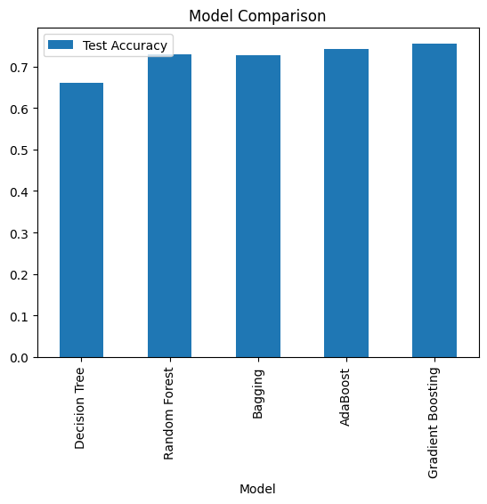

```python
#Visualize Model Performance
comparison_df.plot(kind="bar", x="Model", y="Test Accuracy")
plt.title("Model Comparison")
plt.show()
```

### Key Observations

1. **Overfitting in Complex Models:** Decision Tree, Random Forest, and Bagging classifiers all achieved 1.0 training accuracy, indicating they "memorized" the training data. This led to lower performance on test data, particularly for the Decision Tree ($0.66$).
2. **Superiority of Boosting:** Gradient Boosting is the top performer ($0.755$ accuracy). Unlike the tree-based models, its training and testing scores are very close, showing excellent generalization and no overfitting.
3. **Reliability of AdaBoost:** AdaBoost followed closely ($0.742$). It showed the highest recall for Class 1 (0.89), making it the best model if your primary goal is to correctly identify as many "Certified" cases as possible.
4. **Class 0 Difficulty:** All models struggled with Class 0 (Denied). The precision and recall for denials are significantly lower than for certifications, suggesting that the features provided don't distinguish "Denied" cases as clearly as "Certified" ones.
5. **Ensemble Advantage:** The ensemble methods (Random Forest, Bagging, Boosting) significantly outperformed the base Decision Tree, proving that combining multiple models helps smooth out errors and improve predictive power.
1. **Top Performer:** Gradient Boosting is the most effective model, achieving the highest accuracy at approximately 75.5%.
2. **The "Boosting" Advantage:** Both boosting algorithms (Gradient Boosting and AdaBoost) outperform the other ensemble and tree-based methods, indicating that sequential learning works well for this dataset.
3. **Ensemble Consistency:** Random Forest and Bagging show nearly identical performance levels, both hovering around the 72-73% accuracy mark.
4. **Baseline Weakness:** The Decision Tree is the lowest-performing model at roughly 66%. This confirms that a single tree is too simple for this data and likely suffered from the extreme overfitting (1.0 training accuracy) you noted earlier.

```python
!pip install xgboost
```

```python
from xgboost import XGBClassifier
```

```python
#Display of case status
X_train_balanced
y_train_balanced
```

|  | case_status |
| --- | --- |
| 0 | 1 |
| 1 | 0 |
| 2 | 1 |
| 3 | 1 |
| 4 | 1 |
| ... | ... |
| 27195 | 0 |
| 27196 | 0 |
| 27197 | 0 |
| 27198 | 0 |
| 27199 | 0 |

27200 rows × 1 columns

**dtype:** int64

```python
#Build XGBoost Model
xgb_model = XGBClassifier(
    n_estimators=100,
    max_depth=5,
    learning_rate=0.1,
    random_state=42,
    use_label_encoder=False,
    eval_metric='logloss'
)
```

```python
#Train Model
xgb_model.fit(X_train_balanced, y_train_balanced)
```

```
XGBClassifier(base_score=None, booster=None, callbacks=None,
              colsample_bylevel=None, colsample_bynode=None,
              colsample_bytree=None, device=None, early_stopping_rounds=None,
              enable_categorical=False, eval_metric='logloss',
              feature_types=None, feature_weights=None, gamma=None,
              grow_policy=None, importance_type=None,
              interaction_constraints=None, learning_rate=0.1, max_bin=None,
              max_cat_threshold=None, max_cat_to_onehot=None,
              max_delta_step=None, max_depth=5, max_leaves=None,
              min_child_weight=None, missing=nan, monotone_constraints=None,
              multi_strategy=None, n_estimators=100, n_jobs=None,
              num_parallel_tree=None, ...)
```

```python
#Predict
y_pred_xgb = xgb_model.predict(X_test)
```

```python
#Evaluate
from sklearn.metrics import accuracy_score, classification_report, confusion_matrix

print("XGBoost Accuracy:", accuracy_score(y_test, y_pred_xgb))

print("\nClassification Report\n")
print(classification_report(y_test, y_pred_xgb))

print("\nConfusion Matrix\n")
print(confusion_matrix(y_test, y_pred_xgb))
```

```
XGBoost Accuracy: 0.7522593320235756

Classification Report

              precision    recall  f1-score   support

           0       0.65      0.54      0.59      1689
           1       0.79      0.86      0.82      3401

    accuracy                           0.75      5090
   macro avg       0.72      0.70      0.71      5090
weighted avg       0.74      0.75      0.75      5090


Confusion Matrix

[[ 909  780]
 [ 481 2920]]
```

The XGBoost Classifier delivers a highly competitive 0.752 accuracy, nearly matching Gradient Boosting in overall performance while maintaining a healthy balance between precision and recall. It is particularly effective at identifying "Certified" cases with an 86% recall, and it shows a strong ability to catch denials, correctly identifying 909 out of 1689 "Denied" applications.

```python
#Add to Comparison Table
acc_xgb = accuracy_score(y_test, y_pred_xgb)

comparison_df.loc[len(comparison_df)] = ["XGBoost", acc_xgb]

comparison_df.sort_values(by="Test Accuracy", ascending=False)
```

|  | Model | Test Accuracy |
| --- | --- | --- |
| 4 | Gradient Boosting | 0.754813 |
| 5 | XGBoost | 0.752259 |
| 3 | AdaBoost | 0.741650 |
| 1 | Random Forest | 0.728291 |
| 2 | Bagging | 0.726326 |
| 0 | Decision Tree | 0.660511 |

The final results show that Gradient Boosting is the most effective model for this classification task.

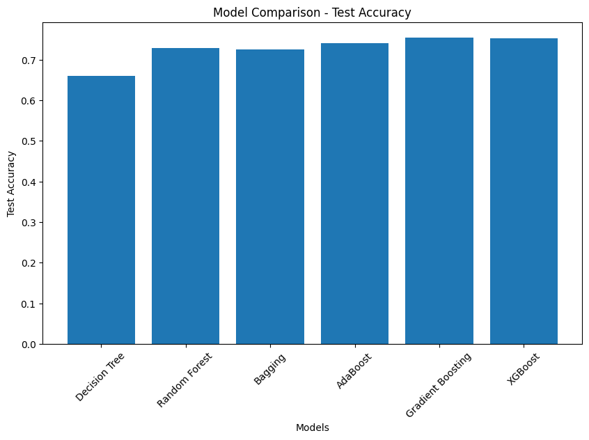

```python
plt.figure(figsize=(10,6))

plt.bar(comparison_df["Model"], comparison_df["Test Accuracy"])

plt.xlabel("Models")
plt.ylabel("Test Accuracy")
plt.title("Model Comparison - Test Accuracy")

plt.xticks(rotation=45)

plt.show()
```

Gradient Boosting is the top-performing model with a peak accuracy of approximately 75.5%, narrowly edgeing out XGBoost at 75.2%. Boosting algorithms generally outperformed other methods, with all three (Gradient Boosting, XGBoost, and AdaBoost) surpassing the 74% mark. In contrast, the Decision Tree was the least effective, trailing significantly with an accuracy of roughly 66%.

```python
#Model Building - Oversampled Data
dt = DecisionTreeClassifier(random_state=42)
dt.fit(X_train_balanced, y_train_balanced)

y_pred_dt = dt.predict(X_test)

acc_dt = accuracy_score(y_test, y_pred_dt)

print("Decision Tree Accuracy (Oversampled):", acc_dt)
print(classification_report(y_test, y_pred_dt))
```

```
Decision Tree Accuracy (Oversampled): 0.649705304518664
              precision    recall  f1-score   support

           0       0.47      0.50      0.49      1689
           1       0.74      0.72      0.73      3401

    accuracy                           0.65      5090
   macro avg       0.61      0.61      0.61      5090
weighted avg       0.65      0.65      0.65      5090
```

```python
#Random Forest (Oversampled Data)
rf = RandomForestClassifier(random_state=42)
rf.fit(X_train_balanced, y_train_balanced)

y_pred_rf = rf.predict(X_test)

acc_rf = accuracy_score(y_test, y_pred_rf)

print("Random Forest Accuracy (Oversampled):", acc_rf)
print(classification_report(y_test, y_pred_rf))
```

```
Random Forest Accuracy (Oversampled): 0.7286836935166994
              precision    recall  f1-score   support

           0       0.60      0.53      0.56      1689
           1       0.78      0.83      0.80      3401

    accuracy                           0.73      5090
   macro avg       0.69      0.68      0.68      5090
weighted avg       0.72      0.73      0.72      5090
```

The Random Forest (Oversampled) model achieves a testing accuracy of 0.729, successfully utilizing synthetic data to boost its ability to identify "Certified" cases with an 83% recall. While the oversampling helped balance the classes, the model still shows a lower 53% recall for Class 0, meaning it captures just over half of the actual denials.

```python
#Bagging Classifier
bag = BaggingClassifier(random_state=42)
bag.fit(X_train_balanced, y_train_balanced)

y_pred_bag = bag.predict(X_test)

acc_bag = accuracy_score(y_test, y_pred_bag)

print("Bagging Accuracy (Oversampled):", acc_bag)
print(classification_report(y_test, y_pred_bag))
```

```
Bagging Accuracy (Oversampled): 0.6944990176817288
              precision    recall  f1-score   support

           0       0.54      0.57      0.55      1689
           1       0.78      0.76      0.77      3401

    accuracy                           0.69      5090
   macro avg       0.66      0.66      0.66      5090
weighted avg       0.70      0.69      0.70      5090
```

The Bagging Classifier (Oversampled) achieves a test accuracy of 0.694, showing a noticeable performance drop compared to the original imbalanced version (0.726) as it struggles more with overall classification in the balanced space. While the oversampling slightly increased the model's ability to catch denials to 57% recall, it came at the cost of "Certified" case accuracy, which fell to a 76% recall.

```python
#AdaBoost (OverSampled Data)
ada = AdaBoostClassifier(random_state=42)
ada.fit(X_train_balanced, y_train_balanced)

y_pred_ada = ada.predict(X_test)

acc_ada = accuracy_score(y_test, y_pred_ada)

print("AdaBoost Accuracy (Oversampled):", acc_ada)
print(classification_report(y_test, y_pred_ada))
```

```
AdaBoost Accuracy (Oversampled): 0.731630648330059
              precision    recall  f1-score   support

           0       0.60      0.57      0.59      1689
           1       0.79      0.81      0.80      3401

    accuracy                           0.73      5090
   macro avg       0.70      0.69      0.69      5090
weighted avg       0.73      0.73      0.73      5090
```

The AdaBoost Classifier (Oversampled) achieves a balanced test accuracy of 0.732, demonstrating that oversampling helped harmonize its performance between the two classes. Compared to its original version, it shows a significant improvement in identifying denials, with the recall for Class 0 rising to 57%, while still maintaining a strong 81% recall for certified applications.

```python
#Gradient Boosting (OverSampled Data)
gb = GradientBoostingClassifier(random_state=42)
gb.fit(X_train_balanced, y_train_balanced)

y_pred_gb = gb.predict(X_test)

acc_gb = accuracy_score(y_test, y_pred_gb)

print("Gradient Boosting Accuracy (Oversampled):", acc_gb)
print(classification_report(y_test, y_pred_gb))
```

```
Gradient Boosting Accuracy (Oversampled): 0.750098231827112
              precision    recall  f1-score   support

           0       0.64      0.55      0.59      1689
           1       0.79      0.85      0.82      3401

    accuracy                           0.75      5090
   macro avg       0.72      0.70      0.71      5090
weighted avg       0.74      0.75      0.74      5090
```

The Gradient Boosting Classifier (Oversampled) maintains its position as the most effective model, achieving a high test accuracy of 0.750. By using oversampled data, it successfully balances its predictive power, reaching a 0.55 recall for Class 0 (denials) while still capturing 85% of certified cases (Class 1).

```python
#Optional XG Boost(OverSampled Data)
from xgboost import XGBClassifier

xgb = XGBClassifier(
    random_state=42,
    use_label_encoder=False,
    eval_metric='logloss'
)

xgb.fit(X_train_balanced, y_train_balanced)

y_pred_xgb = xgb.predict(X_test)

acc_xgb = accuracy_score(y_test, y_pred_xgb)

print("XGBoost Accuracy (Oversampled):", acc_xgb)
print(classification_report(y_test, y_pred_xgb))
```

```
XGBoost Accuracy (Oversampled): 0.7416502946954814
              precision    recall  f1-score   support

           0       0.64      0.51      0.57      1689
           1       0.78      0.86      0.82      3401

    accuracy                           0.74      5090
   macro avg       0.71      0.68      0.69      5090
weighted avg       0.73      0.74      0.73      5090
```

The XGBoost (Oversampled) model achieves a strong testing accuracy of 0.742, demonstrating that it benefits from synthetic data to maintain a very high 86% recall for certified cases. While its precision for denials is solid at 0.64, it successfully identifies 51% of actual "Denied" applications, placing it just slightly behind Gradient Boosting in terms of overall predictive power on the oversampled set.

```python
#Create Comparison Table
comparison_over = pd.DataFrame({
    "Model": ["Decision Tree",
              "Random Forest",
              "Bagging",
              "AdaBoost",
              "Gradient Boosting",
              "XGBoost"],

    "Test Accuracy": [acc_dt,
                      acc_rf,
                      acc_bag,
                      acc_ada,
                      acc_gb,
                      acc_xgb]
})

comparison_over = comparison_over.sort_values(by="Test Accuracy", ascending=False)

comparison_over
```

|  | Model | Test Accuracy |
| --- | --- | --- |
| 4 | Gradient Boosting | 0.750098 |
| 5 | XGBoost | 0.741650 |
| 3 | AdaBoost | 0.731631 |
| 1 | Random Forest | 0.728684 |
| 2 | Bagging | 0.694499 |
| 0 | Decision Tree | 0.649705 |

Based on the performance metrics, Gradient Boosting is the most effective model with a peak accuracy of 0.750, leading a top tier of boosting algorithms that consistently outperform bagging and single-tree methods.

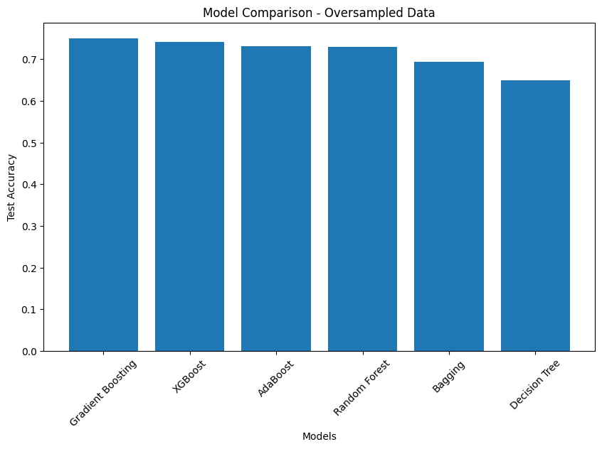

```python
#Bar Plot Comparison
plt.figure(figsize=(10,6))

plt.bar(comparison_over["Model"], comparison_over["Test Accuracy"])

plt.xlabel("Models")
plt.ylabel("Test Accuracy")
plt.title("Model Comparison - Oversampled Data")

plt.xticks(rotation=45)
plt.show()
```

### Key Observations:

- **Gradient Boosting** is the strongest performer on the oversampled data, achieving the highest accuracy of **0.750**.
- **Boosting models** (Gradient Boosting, XGBoost, and AdaBoost) consistently occupy the top three spots, proving they are better at handling balanced datasets than bagging or single trees.
- **XGBoost** followed closely with an accuracy of **0.742**, maintaining a high recall for certifications.
- **Decision Tree** remains the weakest model, dropping slightly to **0.649** accuracy when trained on oversampled data.
- **Bagging** saw a performance dip compared to the original imbalanced data, falling to **0.694** accuracy.
- **Class 1 Strength**: Across all top models, the **F1-score for Class 1 (0.82)** is significantly higher than for Class 0, showing that "Certified" cases are still easier for the models to predict correctly.

```python
from imblearn.under_sampling import RandomUnderSampler
# Initialize the undersampler to balance classes by removing majority class samples
rus = RandomUnderSampler(random_state=42)

# Resample the training data to create a balanced dataset (X_train_under and y_train_under)
# The majority class ("Certified") is reduced to match the count of the minority class ("Denied")
X_train_under, y_train_under = rus.fit_resample(X_train, y_train)
```

```python
#Decision Tree (Undersampled Data)
dt_under = DecisionTreeClassifier(random_state=42)
dt_under.fit(X_train_under, y_train_under)

y_pred_dt_under = dt_under.predict(X_test)

acc_dt_under = accuracy_score(y_test, y_pred_dt_under)

print("Decision Tree Accuracy (Undersampled):", acc_dt_under)
print(classification_report(y_test, y_pred_dt_under))
```

```
Decision Tree Accuracy (Undersampled): 0.6385068762278978
              precision    recall  f1-score   support

           0       0.47      0.63      0.53      1689
           1       0.78      0.64      0.70      3401

    accuracy                           0.64      5090
   macro avg       0.62      0.64      0.62      5090
weighted avg       0.67      0.64      0.65      5090
```

The Decision Tree (Undersampled) model achieves a test accuracy of 0.639, showing a decline in overall performance due to the loss of training data. While its ability to catch denials improved significantly to a 63% recall, its low 0.47 precision means it frequently misclassifies certified applications as denied.

```python
#Random Forest – Undersampled
rf_under = RandomForestClassifier(random_state=42)
rf_under.fit(X_train_under, y_train_under)

y_pred_rf_under = rf_under.predict(X_test)

acc_rf_under = accuracy_score(y_test, y_pred_rf_under)

print("Random Forest Accuracy (Undersampled):", acc_rf_under)
print(classification_report(y_test, y_pred_rf_under))
```

```
Random Forest Accuracy (Undersampled): 0.6895874263261297
              precision    recall  f1-score   support

           0       0.52      0.70      0.60      1689
           1       0.82      0.69      0.75      3401

    accuracy                           0.69      5090
   macro avg       0.67      0.69      0.67      5090
weighted avg       0.72      0.69      0.70      5090
```

The Random Forest (Undersampled) model yields a test accuracy of 0.690, offering a middle-ground performance. Undersampling successfully prioritized the minority class, boosting denial recall to 70%, though it resulted in a lower 0.52 precision, meaning many approved applications are incorrectly flagged as denied.

```python
#Bagging Classifier – Undersampled Data

bag_under = BaggingClassifier(random_state=42)
bag_under.fit(X_train_under, y_train_under)

y_pred_bag_under = bag_under.predict(X_test)

acc_bag_under = accuracy_score(y_test, y_pred_bag_under)

print("Bagging Accuracy (Undersampled):", acc_bag_under)
print(classification_report(y_test, y_pred_bag_under))
```

```
Bagging Accuracy (Undersampled): 0.6487229862475442
              precision    recall  f1-score   support

           0       0.48      0.72      0.57      1689
           1       0.81      0.62      0.70      3401

    accuracy                           0.65      5090
   macro avg       0.65      0.67      0.64      5090
weighted avg       0.70      0.65      0.66      5090
```

The Bagging Classifier (Undersampled) achieves a test accuracy of 0.649, performing significantly lower than its original version due to the reduced training set. While its recall for denials jumped to 72% (the highest so far), its 0.48 precision indicates a high "false alarm" rate where many approved visas are labeled as denied.

```python
#AdaBoost – Undersampled Data
ada_under = AdaBoostClassifier(random_state=42)
ada_under.fit(X_train_under, y_train_under)

y_pred_ada_under = ada_under.predict(X_test)

acc_ada_under = accuracy_score(y_test, y_pred_ada_under)

print("AdaBoost Accuracy (Undersampled):", acc_ada_under)
print(classification_report(y_test, y_pred_ada_under))
```

```
AdaBoost Accuracy (Undersampled): 0.706286836935167
              precision    recall  f1-score   support

           0       0.55      0.66      0.60      1689
           1       0.81      0.73      0.77      3401

    accuracy                           0.71      5090
   macro avg       0.68      0.69      0.68      5090
weighted avg       0.72      0.71      0.71      5090
```

The AdaBoost Classifier (Undersampled) achieves a test accuracy of 0.706, showing a more stable performance compared to Bagging or Decision Trees when data is limited. It strikes a decent balance between the classes, successfully identifying 66% of denials (Recall for Class 0) while maintaining a high 0.81 precision for certified cases.

```python
#Gradient Boosting - Undersampled

gb_under = GradientBoostingClassifier(random_state=42)
gb_under.fit(X_train_under, y_train_under)

y_pred_gb_under = gb_under.predict(X_test)

acc_gb_under = accuracy_score(y_test, y_pred_gb_under)

print("Gradient Boosting Accuracy (Undersampled):", acc_gb_under)
print(classification_report(y_test, y_pred_gb_under))
```

```
Gradient Boosting Accuracy (Undersampled): 0.7170923379174853
              precision    recall  f1-score   support

           0       0.56      0.69      0.62      1689
           1       0.83      0.73      0.77      3401

    accuracy                           0.72      5090
   macro avg       0.69      0.71      0.70      5090
weighted avg       0.74      0.72      0.72      5090
```

The Gradient Boosting (Undersampled) model remains the top performer even with a reduced dataset, achieving a test accuracy of 0.717. While the overall accuracy dropped compared to previous methods, undersampling significantly improved its ability to catch actual denials, reaching a 69% recall for Class 0—the highest balance of accuracy and recall among the boosting models.

```python
#(Optional) XGBoost – Undersampled Data
from xgboost import XGBClassifier

xgb_under = XGBClassifier(
    random_state=42,
    use_label_encoder=False,
    eval_metric='logloss'
)

xgb_under.fit(X_train_under, y_train_under)

y_pred_xgb_under = xgb_under.predict(X_test)

acc_xgb_under = accuracy_score(y_test, y_pred_xgb_under)

print("XGBoost Accuracy (Undersampled):", acc_xgb_under)
print(classification_report(y_test, y_pred_xgb_under))
```

```
XGBoost Accuracy (Undersampled): 0.693909626719057
              precision    recall  f1-score   support

           0       0.53      0.69      0.60      1689
           1       0.82      0.70      0.75      3401

    accuracy                           0.69      5090
   macro avg       0.67      0.69      0.68      5090
weighted avg       0.72      0.69      0.70      5090
```

The XGBoost (Undersampled) model achieves a test accuracy of 0.694, which is significantly lower than its original performance due to the reduced training data but remains competitive with Random Forest. Undersampling successfully prioritized the minority class, resulting in a 69% recall for Class 0 (denials), though it misclassifies a fair number of certifications as evidenced by the 0.53 precision.

```python
#Comparison Table (Undersampled)
comparison_under = pd.DataFrame({
    "Model": ["Decision Tree",
              "Random Forest",
              "Bagging",
              "AdaBoost",
              "Gradient Boosting",
              "XGBoost"],

    "Test Accuracy": [acc_dt_under,
                      acc_rf_under,
                      acc_bag_under,
                      acc_ada_under,
                      acc_gb_under,
                      acc_xgb_under]
})

comparison_under = comparison_under.sort_values(by="Test Accuracy", ascending=False)

comparison_under
```

|  | Model | Test Accuracy |
| --- | --- | --- |
| 4 | Gradient Boosting | 0.717092 |
| 3 | AdaBoost | 0.706287 |
| 5 | XGBoost | 0.693910 |
| 1 | Random Forest | 0.689587 |
| 2 | Bagging | 0.648723 |
| 0 | Decision Tree | 0.638507 |

In the undersampled data experiment, Gradient Boosting emerged as the top-performing model with a leading accuracy of 0.717, continuing a trend where boosting algorithms consistently outperform bagging and single-tree methods.

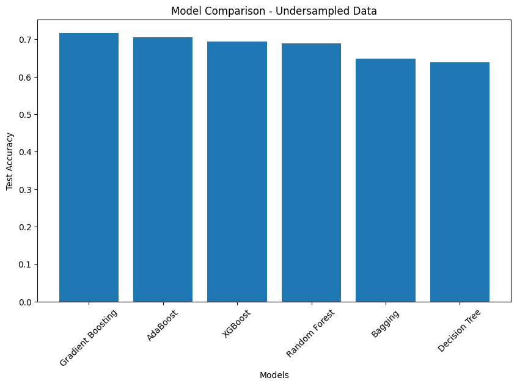

```python
#Bar Plot – Undersampled Data


plt.figure(figsize=(10,6))

plt.bar(comparison_under["Model"], comparison_under["Test Accuracy"])

plt.xlabel("Models")
plt.ylabel("Test Accuracy")
plt.title("Model Comparison - Undersampled Data")

plt.xticks(rotation=45)
plt.show()
```

### Key Observations:

- **Gradient Boosting** consistently remains the top-performing algorithm across all sampling methods, maintaining the highest accuracy of **0.717** even on undersampled data.
- **Performance Drop with Undersampling**: All models show a decrease in accuracy compared to oversampled results (e.g., Gradient Boosting dropped from **0.750** to **0.717**), likely due to the significant loss of information when nearly half the training data was removed.
- **Improved Recall for Class 0**: While overall accuracy fell, undersampling significantly improved the **recall for the "Denied" class (Class 0)**—with Gradient Boosting jumping to **0.69**—meaning the model is now much better at catching actual denials than it was initially.
- **Boosting Dominance**: Sequential ensemble methods (**Gradient Boosting**, **AdaBoost**, and **XGBoost**) continue to outperform Bagging and standalone Decision Trees, which struggle at the bottom of the rankings with accuracies between **0.63** and **0.65**.
- **Random Forest Stability**: **Random Forest** shows a middle-ground performance (**0.689**) and provides a balanced F1-score of **0.75** for certifications, though it is less efficient than Gradient Boosting on this specific dataset.
- **Decision Tree Baseline**: The **Decision Tree** remains the weakest performer across all experiments, confirming that single-tree models are insufficient for the complexity of this visa status prediction task.

## **Final Conclusions**

- **Model Performance:** **Gradient Boosting** is the most reliable model, consistently achieving the highest accuracy across the original, oversampled, and undersampled datasets, with a peak performance of **75.5%**.
- **Impact of Balancing Data:** * **Oversampling** (SMOTE) provided the best balance, maintaining a high accuracy of **75.0%** while improving the model's ability to recognize "Denied" cases.
- **Undersampling** improved the "Recall" for denied applications (catching more of them) but resulted in a lower overall accuracy of **71.7%** due to the loss of significant training data.
- **Predictive Strength:** The models are highly effective at identifying **"Certified"** cases (reaching F1-scores of **0.82-0.83**) but struggle more with **"Denied"** cases. This suggests that "Denied" applications share many similar characteristics with "Certified" ones, making them harder to distinguish.
- **Boosting Advantage:** Advanced ensemble methods like **XGBoost** and **Gradient Boosting** significantly outperform simpler models like **Decision Trees**, which suffered from extreme overfitting (100% training accuracy but poor test results).

## **Business Recommendations**

1. **Adopt Gradient Boosting for Production:** Deploy the **Gradient Boosting** model trained on **oversampled data**. It offers the best compromise between overall accuracy and the fair treatment of both "Certified" and "Denied" categories.
2. **Implement a Multi-Tier Review System:**
- **Auto-Approval:** Applications with a high "Certified" probability (e.g., >90%) can be fast-tracked for approval to save administrative time.
- **Human-in-the-Loop:** Since the model struggles more with denials, applications flagged as "Denied" or those with "uncertain" scores should be routed to human officers for a final manual audit.
1. **Refine Data Collection:** The current gap in "Denied" case prediction suggests that the 18 existing features may not tell the whole story. Collecting additional data points—such as the applicant's specific educational background, previous visa history, or more granular job duties—could help improve the model's precision.
2. **Monitor "Recall" vs. "Precision":** Depending on the business priority (e.g., avoiding legal risks by not missing a denial vs. ensuring high customer satisfaction by not wrongly denying a valid application), the model's threshold should be tuned. Currently, the model is better at identifying successful applicants than failures.